# Star Hotels Project

## Context

A significant number of hotel bookings are called-off due to cancellations or no-shows. The typical reasons for cancellations include change of plans, scheduling conflicts, etc. This is often made easier by the option to do so free of charge or preferably at a low cost which is beneficial to hotel guests but it is a less desirable and possibly revenue-diminishing factor for hotels to deal with. Such losses are particularly high on last-minute cancellations.

The new technologies involving online booking channels have dramatically changed customers’ booking possibilities and behavior. This adds a further dimension to the challenge of how hotels handle cancellations, which are no longer limited to traditional booking and guest characteristics.

The cancellation of bookings impact a hotel on various fronts:

- Loss of resources (revenue) when the hotel cannot resell the room.
- Additional costs of distribution channels by increasing commissions or paying for publicity to help sell these rooms.
- Lowering prices last minute, so the hotel can resell a room, resulting in reducing the profit margin.
- Human resources to make arrangements for the guests.

## Objective

The increasing number of cancellations calls for a Machine Learning based solution that can help in predicting which booking is likely to be canceled. Star Hotels Group has a chain of hotels in Portugal, they are facing problems with the high number of booking cancellations and have reached out to your firm for data-driven solutions. You as a data scientist have to analyze the data provided to find which factors have a high influence on booking cancellations, build a predictive model that can predict which booking is going to be canceled in advance, and help in formulating profitable policies for cancellations and refunds.

## Data Description

The data contains the different attributes of customers' booking details. The detailed data dictionary is given below.

**Data Dictionary**

- no_of_adults: Number of adults
- no_of_children: Number of Children
- no_of_weekend_nights: Number of weekend nights (Saturday or Sunday) the guest stayed or booked to stay at the hotel
- no_of_week_nights: Number of week nights (Monday to Friday) the guest stayed or booked to stay at the hoteal
- type_of_meal_plan: Type of meal plan booked by the customer:
  - Not Selected – No meal plan selected
  - Meal Plan 1 – Breakfast
  - Meal Plan 2 – Half board (breakfast and one other meal)
  - Meal Plan 3 – Full board (breakfast, lunch, and dinner)
- required_car_parking_space: Does the customer require a car parking space? (0 - No, 1- Yes)
- room_type_reserved: Type of room reserved by the customer. The values are ciphered (encoded) by Star Hotels.
- lead_time: Number of days between the date of booking and the arrival date
- arrival_year: Year of arrival date
- arrival_month: Month of arrival date
- arrival_date: Date of the month
- market_segment_type: Market segment designation.
- repeated_guest: Is the customer a repeated guest? (0 - No, 1- Yes)
- no_of_previous_cancellations: Number of previous bookings that were canceled by the customer prior to the current booking
- no_of_previous_bookings_not_canceled: Number of previous bookings not canceled by the customer prior to the current booking
- avg_price_per_room: Average price per day of the reservation; prices of the rooms are dynamic. (in euros)
- no_of_special_requests: Total number of special requests made by the customer (e.g. high floor, view from the room, etc)
- booking_status: Flag indicating if the booking was canceled or not.

```python
import pandas as pd

import matplotlib.pyplot as plt

import seaborn as sns
```

```python
from sklearn.linear_model import LogisticRegression

from sklearn.model_selection import train_test_split # Sklearn package's randomized data splitting function

from sklearn.metrics import plot_confusion_matrix
```

```python
df = pd.read_csv("StarHotelsGroup.csv")
```

## Data Overview

```python
df.shape
```

```
(56926, 18)
```

```python
df.head()
```

|  | no_of_adults | no_of_children | no_of_weekend_nights | no_of_week_nights | type_of_meal_plan | required_car_parking_space | room_type_reserved | lead_time | arrival_year | arrival_month | arrival_date | market_segment_type | repeated_guest | no_of_previous_cancellations | no_of_previous_bookings_not_canceled | avg_price_per_room | no_of_special_requests | booking_status |
| --- | --- | --- | --- | --- | --- | --- | --- | --- | --- | --- | --- | --- | --- | --- | --- | --- | --- | --- |
| 0 | 2 | 0 | 1 | 2 | Meal Plan 1 | 0 | Room_Type 1 | 224 | 2017 | 10 | 2 | Offline | 0 | 0 | 0 | 65.00 | 0 | Not_Canceled |
| 1 | 2 | 0 | 2 | 3 | Not Selected | 0 | Room_Type 1 | 5 | 2018 | 11 | 6 | Online | 0 | 0 | 0 | 106.68 | 1 | Not_Canceled |
| 2 | 1 | 0 | 2 | 1 | Meal Plan 1 | 0 | Room_Type 1 | 1 | 2018 | 2 | 28 | Online | 0 | 0 | 0 | 60.00 | 0 | Canceled |
| 3 | 2 | 0 | 0 | 2 | Meal Plan 1 | 0 | Room_Type 1 | 211 | 2018 | 5 | 20 | Online | 0 | 0 | 0 | 100.00 | 0 | Canceled |
| 4 | 3 | 0 | 0 | 3 | Not Selected | 0 | Room_Type 1 | 277 | 2019 | 7 | 13 | Online | 0 | 0 | 0 | 89.10 | 2 | Canceled |

```python
df.dtypes
```

```
no_of_adults                              int64
no_of_children                            int64
no_of_weekend_nights                      int64
no_of_week_nights                         int64
type_of_meal_plan                        object
required_car_parking_space                int64
room_type_reserved                       object
lead_time                                 int64
arrival_year                              int64
arrival_month                             int64
arrival_date                              int64
market_segment_type                      object
repeated_guest                            int64
no_of_previous_cancellations              int64
no_of_previous_bookings_not_canceled      int64
avg_price_per_room                      float64
no_of_special_requests                    int64
booking_status                           object
dtype: object
```

```python
df.describe().T
```

|  | count | mean | std | min | 25% | 50% | 75% | max |
| --- | --- | --- | --- | --- | --- | --- | --- | --- |
| no_of_adults | 56926.0 | 1.875856 | 0.518667 | 0.0 | 2.0 | 2.0 | 2.0 | 4.0 |
| no_of_children | 56926.0 | 0.110723 | 0.408885 | 0.0 | 0.0 | 0.0 | 0.0 | 10.0 |
| no_of_weekend_nights | 56926.0 | 0.835840 | 0.875900 | 0.0 | 0.0 | 1.0 | 2.0 | 8.0 |
| no_of_week_nights | 56926.0 | 2.261901 | 1.432371 | 0.0 | 1.0 | 2.0 | 3.0 | 17.0 |
| required_car_parking_space | 56926.0 | 0.026332 | 0.160123 | 0.0 | 0.0 | 0.0 | 0.0 | 1.0 |
| lead_time | 56926.0 | 93.713909 | 92.408296 | 0.0 | 21.0 | 65.0 | 142.0 | 521.0 |
| arrival_year | 56926.0 | 2018.248340 | 0.644619 | 2017.0 | 2018.0 | 2018.0 | 2019.0 | 2019.0 |
| arrival_month | 56926.0 | 6.490215 | 3.027185 | 1.0 | 4.0 | 6.0 | 9.0 | 12.0 |
| arrival_date | 56926.0 | 15.635913 | 8.718717 | 1.0 | 8.0 | 16.0 | 23.0 | 31.0 |
| repeated_guest | 56926.0 | 0.024664 | 0.155099 | 0.0 | 0.0 | 0.0 | 0.0 | 1.0 |
| no_of_previous_cancellations | 56926.0 | 0.020939 | 0.326142 | 0.0 | 0.0 | 0.0 | 0.0 | 13.0 |
| no_of_previous_bookings_not_canceled | 56926.0 | 0.167902 | 1.943647 | 0.0 | 0.0 | 0.0 | 0.0 | 72.0 |
| avg_price_per_room | 56926.0 | 109.610570 | 38.256075 | 0.0 | 85.0 | 105.0 | 129.7 | 540.0 |
| no_of_special_requests | 56926.0 | 0.666040 | 0.814257 | 0.0 | 0.0 | 0.0 | 1.0 | 5.0 |

The following are the observations in the file :\ 1) The file contains 56926 rows with 18 columns\ 2)There are four categorical columns in the file type_of_meal_plan ,room_type_reserved,market_segment_type,market_segment_type\ 3) The target variable is Object with values Cancelled & Not_Cancelled\ 4)Other columns are numerical

## Univariate Analysis

```python
df1= df[['no_of_adults', 'no_of_children', 'no_of_weekend_nights',
       'no_of_week_nights', 'type_of_meal_plan', 'required_car_parking_space',
       'room_type_reserved',  'arrival_year', 'arrival_month',
        'market_segment_type', 'repeated_guest',
       'no_of_previous_cancellations',
        'no_of_special_requests', 'booking_status']]
```

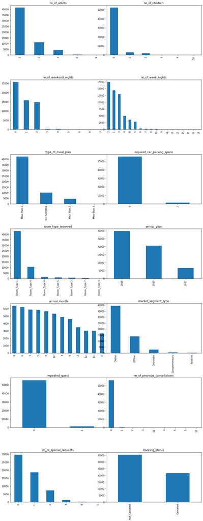

```python
fig, axs = plt.subplots(7,2, figsize=(15, 40), facecolor='w', edgecolor='k')
fig.subplots_adjust(hspace = .5, wspace=.001)

axs = axs.ravel()
for i,x in enumerate(df1.columns):
    df1[x].value_counts().plot(kind='bar',ax=axs[i])
    axs[i].set_title(x)
```

## Observation:

[output not shown]

```python
columns =['no_of_adults',
 'no_of_children',
 'no_of_weekend_nights',
 'no_of_week_nights',
 'required_car_parking_space',
 'lead_time',
 'arrival_year',
 'arrival_month',
 'arrival_date',
 'repeated_guest',
 'no_of_previous_cancellations',
 'no_of_previous_bookings_not_canceled',
 'avg_price_per_room',
 'no_of_special_requests']
```

```python
%%javascript
IPython.OutputArea.prototype._should_scroll = function(lines) {
    return false;
}
```

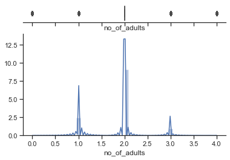

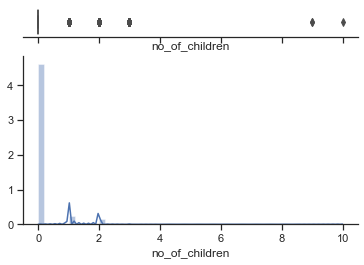

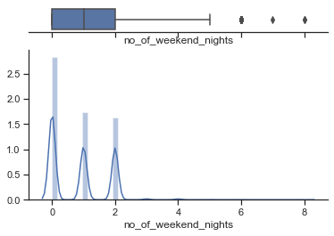

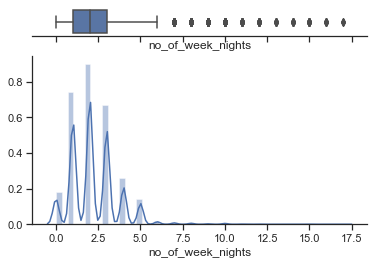

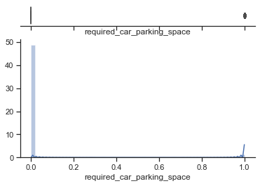

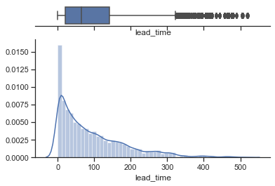

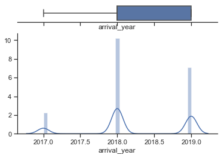

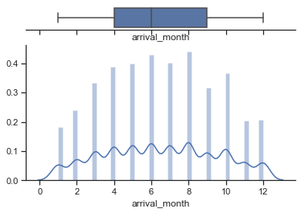

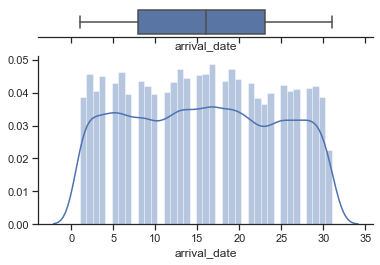

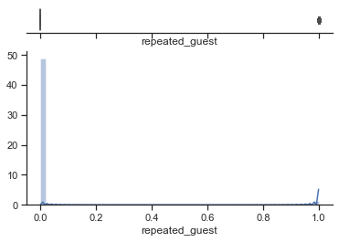

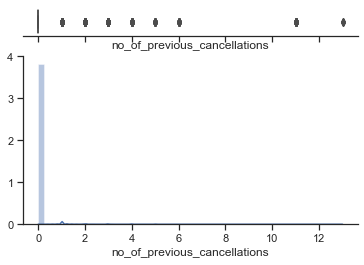

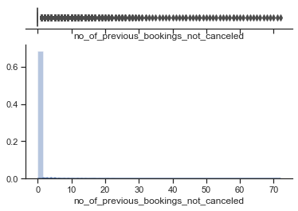

[2 more figures not shown]

```python
sns.set(style="ticks")

for col in columns:
    f, (ax_box, ax_hist) = plt.subplots(2, sharex=True,
                                    gridspec_kw={"height_ratios": (.15, .85)})

    sns.boxplot(df[col], ax=ax_box)
    sns.distplot(df[col], ax=ax_hist)

    ax_box.set(yticks=[])
    sns.despine(ax=ax_hist)
    sns.despine(ax=ax_box, left=True)
```

## Bivariate Analyis

```python
df1=df.groupby(['arrival_year', 'arrival_month', 'booking_status']).size().reset_index(name='count')
```

```python
df1['year_month'] = df["arrival_year"].astype(str) + "-"+ df["arrival_month"].astype(str)
```

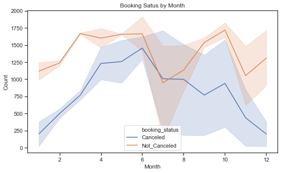

```python
fig, axs = plt.subplots(1, 1,
                        figsize =(8, 5),
                        tight_layout = True)
sns.lineplot(data=df1, x="arrival_month", y="count",hue="booking_status")
plt.title('Booking Satus by Month')
plt.xlabel('Month')
plt.ylabel('Count')
plt.show()
```

## Observations:

[output not shown]

```python
df2=df1[['year_month']]
```

```python
df2['Cancelled'] = df1.loc[df1.booking_status == 'Canceled']['count']

df2['Not_Canceled'] = df1.loc[df1.booking_status == 'Not_Canceled']['count']
```

```python
df2.fillna(0,inplace=True)
```

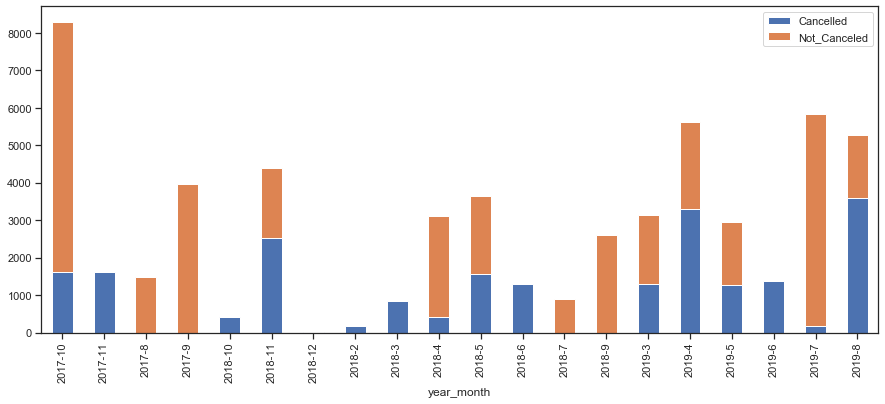

```python
df2.groupby(['year_month']).sum().plot(kind='bar', stacked=True,figsize =(15, 6))
```

## Observation:

[output not shown]

```
<function matplotlib.pyplot.show(*args, **kw)>
```

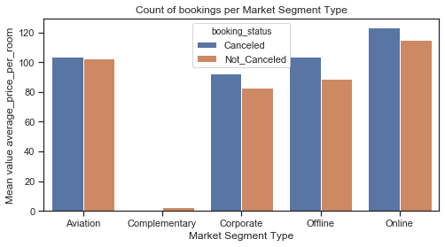

```python
fig, ax = plt.subplots(figsize=(8, 4))

df2=df.groupby(['market_segment_type','booking_status']).mean().reset_index()
sns.barplot(x="market_segment_type",y="avg_price_per_room",hue="booking_status",data=df2)
plt.title('Count of bookings per Market Segment Type')
plt.xlabel('Market Segment Type')
plt.ylabel('Mean value average_price_per_room')
plt.show
##.plot(kind='bar', stacked=True,figsize =(15, 6))
```

[figure not shown]

```python
fig, ax = plt.subplots(figsize=(8, 4))
plt.title('Count of bookings per Market Segment Type')
df2=df.groupby(['market_segment_type','booking_status']).count().reset_index()
sns.barplot(x="market_segment_type",y="avg_price_per_room",hue="booking_status",data=df2)
plt.xlabel('Market Segment Type')
plt.ylabel('Count of Bookings')
plt.show()
```

## Observation :

```
1) The cancelled Average room price has different from Non-Canceleld avearge price
2) Most of the bookings are from online
```

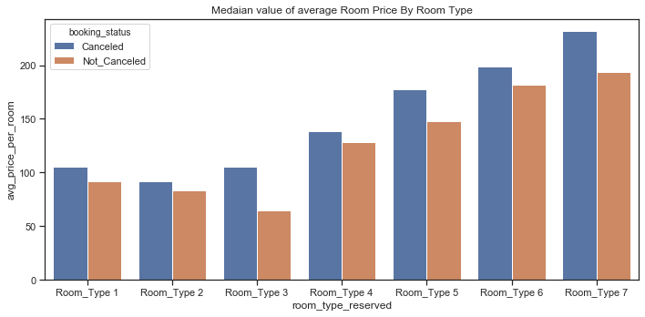

```python
# Creating histogram
fig, axs = plt.subplots(1, 1,
                        figsize =(10, 5),
                        tight_layout = True)
plt.title('Medaian value of average Room Price By Room Type')
plt.xlabel('Price By Room Type')
plt.ylabel('Average Room price')
df2=df.groupby(['room_type_reserved','booking_status']).median().reset_index()
sns.barplot(x="room_type_reserved",y="avg_price_per_room",hue="booking_status",data=df2)
```

```python
df['year_month'] = df["arrival_year"].astype(str) + "-"+ df["arrival_month"].astype(str)
```

```python
df2=df.groupby(['year_month','booking_status']).count().reset_index()
```

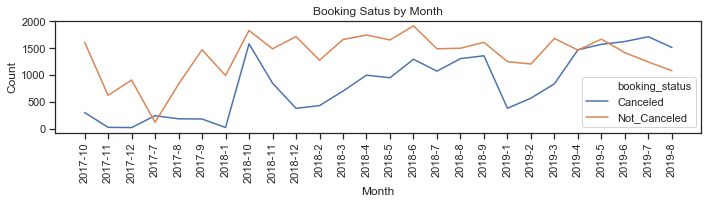

```python
fig, axs = plt.subplots(1, 1,
                        figsize =(10, 3),
                        tight_layout = True)
sns.lineplot(data=df2, x="year_month", y="avg_price_per_room",hue="booking_status")
plt.xticks(rotation=90)
plt.title('Booking Satus by Month')
plt.xlabel('Month')
plt.ylabel('Count')
plt.show()
```

## Data Preprocessing

```python
df1=df
```

```python
dummy=pd.get_dummies(df1["type_of_meal_plan"],prefix="type_of_meal_plan")
df1=df1.merge(dummy,left_index=True,right_index=True)

dummy=pd.get_dummies(df1["room_type_reserved"],prefix="room_type_reserved")
df1=df1.merge(dummy,left_index=True,right_index=True)

dummy=pd.get_dummies(df1["market_segment_type"],prefix="market_segment_type")
df1=df1.merge(dummy,left_index=True,right_index=True)
```

```python
df1.booking_status.replace(to_replace=['Not_Canceled', 'Canceled'], value=[0, 1],inplace=True)
```

```python
df1.drop(['type_of_meal_plan','room_type_reserved','market_segment_type','year_month',
          'arrival_year','arrival_date'], axis=1, inplace=True)
```

Get dummies for the categorical columns. And change the Booking Status to 0/1 based on the Cancelled / Not Cancelled

```python
df1.isnull().sum()
```

```
no_of_adults                            0
no_of_children                          0
no_of_weekend_nights                    0
no_of_week_nights                       0
required_car_parking_space              0
lead_time                               0
arrival_month                           0
repeated_guest                          0
no_of_previous_cancellations            0
no_of_previous_bookings_not_canceled    0
avg_price_per_room                      0
no_of_special_requests                  0
booking_status                          0
type_of_meal_plan_Meal Plan 1_x         0
type_of_meal_plan_Meal Plan 2_x         0
type_of_meal_plan_Meal Plan 3_x         0
type_of_meal_plan_Not Selected_x        0
room_type_reserved_Room_Type 1_x        0
room_type_reserved_Room_Type 2_x        0
room_type_reserved_Room_Type 3_x        0
room_type_reserved_Room_Type 4_x        0
room_type_reserved_Room_Type 5_x        0
room_type_reserved_Room_Type 6_x        0
room_type_reserved_Room_Type 7_x        0
market_segment_type_Aviation_x          0
market_segment_type_Complementary_x     0
market_segment_type_Corporate_x         0
market_segment_type_Offline_x           0
market_segment_type_Online_x            0
type_of_meal_plan_Meal Plan 1_y         0
type_of_meal_plan_Meal Plan 2_y         0
type_of_meal_plan_Meal Plan 3_y         0
type_of_meal_plan_Not Selected_y        0
room_type_reserved_Room_Type 1_y        0
room_type_reserved_Room_Type 2_y        0
room_type_reserved_Room_Type 3_y        0
room_type_reserved_Room_Type 4_y        0
room_type_reserved_Room_Type 5_y        0
room_type_reserved_Room_Type 6_y        0
room_type_reserved_Room_Type 7_y        0
market_segment_type_Aviation_y          0
market_segment_type_Complementary_y     0
market_segment_type_Corporate_y         0
market_segment_type_Offline_y           0
market_segment_type_Online_y            0
dtype: int64
```

No Null values , so no data imputation needed.

Heat Map fo the corelation of columns

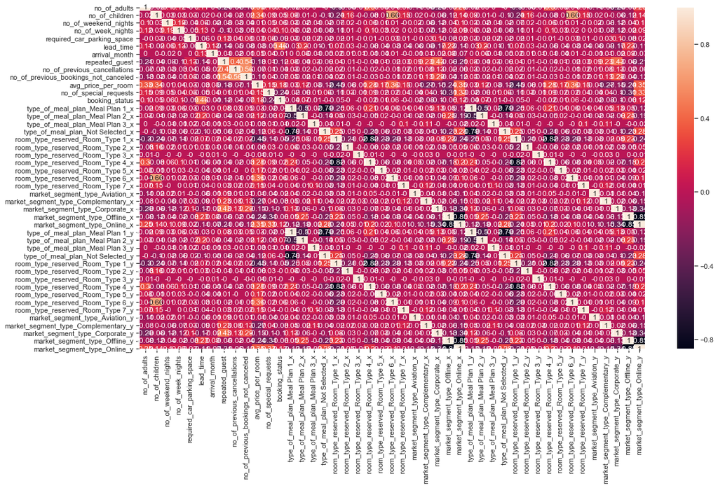

```python
corr = round(df1.corr(),2)
fig, ax = plt.subplots(figsize=(18, 10))
sns.heatmap(corr,annot=True)
```

```python
X = df1.drop(['booking_status'], axis=1)
# the dependent variable
y = df1[['booking_status']]
```

## Top 20 features based on ensemble

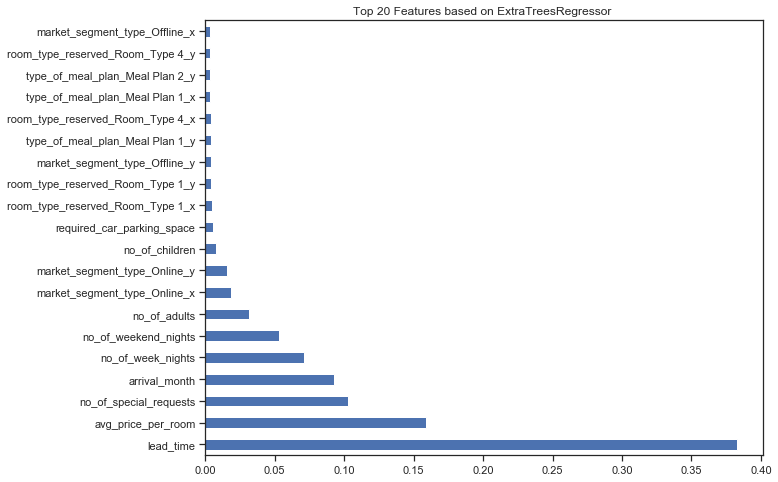

```python
fig, ax = plt.subplots(figsize=(10, 8))
from sklearn.ensemble import ExtraTreesRegressor
import matplotlib.pyplot as plt
model = ExtraTreesRegressor()
model.fit(X,y)
plt.title('Top 20 Features based on ExtraTreesRegressor ', fontsize=12)
#print(model.feature_importances_) #use inbuilt class feature_importances of tree based classifiers
#plot graph of feature importances for better visualization
feat_importances = pd.Series(model.feature_importances_, index=X.columns)
feat_importances.nlargest(20).plot(kind='barh')
plt.show()
```

## Logistic Regression Model

```python
X = df1[feat_importances.nlargest(10).index]
#X = df1.drop(['booking_status'],axis=1)
# the dependent variable
y = df1[['booking_status']]
```

```python
X_train, X_test, y_train, y_test = train_test_split(X, y, random_state=42)
```

```python
from sklearn.preprocessing import StandardScaler
sc = StandardScaler()
X_train = sc.fit_transform(X_train)
X_test = sc.transform (X_test)
```

```python
model =  LogisticRegression()
model.fit(X_train, y_train)
```

```
LogisticRegression(C=1.0, class_weight=None, dual=False, fit_intercept=True,
                   intercept_scaling=1, l1_ratio=None, max_iter=100,
                   multi_class='auto', n_jobs=None, penalty='l2',
                   random_state=None, solver='lbfgs', tol=0.0001, verbose=0,
                   warm_start=False)
```

```python
y_predict = model.predict(X_test)
from sklearn import metrics #Import scikit-learn metrics module for accuracy calculation
```

```python
# Model Accuracy, how often is the classifier correct?
print("Accuracy:",metrics.accuracy_score(y_test, y_pred))

print("F1 Score of the Logistic Regression Model : " , f1_score(y_test, y_predict))
```

[output not shown]

```
No Skill: ROC AUC=0.500
Logistic: ROC AUC=0.856
```

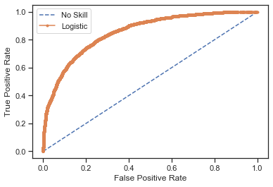

```python
from sklearn.metrics import roc_curve
from sklearn.metrics import roc_auc_score
from matplotlib import pyplot

ns_probs = [0 for _ in range(len(y_test))]

# predict probabilities
lr_probs = model.predict_proba(X_test)
# keep probabilities for the positive outcome only
lr_probs = lr_probs[:, 1]
# calculate scores
ns_auc = roc_auc_score(y_test, ns_probs)
lr_auc = roc_auc_score(y_test, lr_probs)
# summarize scores
print('No Skill: ROC AUC=%.3f' % (ns_auc))
print('Logistic: ROC AUC=%.3f' % (lr_auc))
# calculate roc curves
ns_fpr, ns_tpr, _ = roc_curve(y_test, ns_probs)
lr_fpr, lr_tpr, _ = roc_curve(y_test, lr_probs)
# plot the roc curve for the model
pyplot.plot(ns_fpr, ns_tpr, linestyle='--', label='No Skill')
pyplot.plot(lr_fpr, lr_tpr, marker='.', label='Logistic')
# axis labels
pyplot.xlabel('False Positive Rate')
pyplot.ylabel('True Positive Rate')
# show the legend
pyplot.legend()
# show the plot
pyplot.show()
```

```python
from sklearn.metrics import f1_score
print("F1 Score of the Logistic Regression Model : " , f1_score(y_test, y_predict))
```

```
F1 Score of the Logistic Regression Model :  0.695327836670593
```

## Decision Tree

```python
from sklearn.tree import DecisionTreeClassifier # Import Decision Tree Classifier
```

```python
# Create Decision Tree classifer object
clf = DecisionTreeClassifier()

# Train Decision Tree Classifer
clf = clf.fit(X_train,y_train)

#Predict the response for test dataset
y_pred = clf.predict(X_test)
```

```python
# Model Accuracy, how often is the classifier correct?
print("Accuracy:",metrics.accuracy_score(y_test, y_pred))
print("F1 Score of the Decision Regression Model : " , f1_score(y_test, y_predict))
```

```
Accuracy: 0.8466132658797078
F1 Score of the Decision Regression Model :  0.695327836670593
```

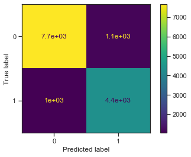

```python
plot_confusion_matrix(clf, X_test, y_test)
plt.show()
```

## Optimizing the Decision Trees

```python
from sklearn.model_selection import GridSearchCV
```

```python
criterion = ['gini', 'entropy']
max_depth = [2,3,4,5]

parameters = dict(criterion=criterion,
                      max_depth=max_depth)
```

# parameters

```python
clf_GS = GridSearchCV(DecisionTreeClassifier(), parameters)
clf_GS.fit(X, y)
```

```
GridSearchCV(cv=None, error_score=nan,
             estimator=DecisionTreeClassifier(ccp_alpha=0.0, class_weight=None,
                                              criterion='gini', max_depth=None,
                                              max_features=None,
                                              max_leaf_nodes=None,
                                              min_impurity_decrease=0.0,
                                              min_impurity_split=None,
                                              min_samples_leaf=1,
                                              min_samples_split=2,
                                              min_weight_fraction_leaf=0.0,
                                              presort='deprecated',
                                              random_state=None,
                                              splitter='best'),
             iid='deprecated', n_jobs=None,
             param_grid={'criterion': ['gini', 'entropy'],
                         'max_depth': [2, 3, 4, 5]},
             pre_dispatch='2*n_jobs', refit=True, return_train_score=False,
             scoring=None, verbose=0)
```

```python
# Create Decision Tree classifer object
clf = DecisionTreeClassifier(criterion="gini",max_depth=5)

# Train Decision Tree Classifer
clf = clf.fit(X_train,y_train)

#Predict the response for test dataset
y_pred = clf.predict(X_test)

# Model Accuracy, how often is the classifier correct?
print("Accuracy:",metrics.accuracy_score(y_test, y_pred))

print("F1 Score of the Decision Regression Model : " , f1_score(y_test, y_predict))
```

```
Accuracy: 0.8163996627318718
F1 Score of the Decision Regression Model :  0.695327836670593
```

## Visualizing Decision Trees

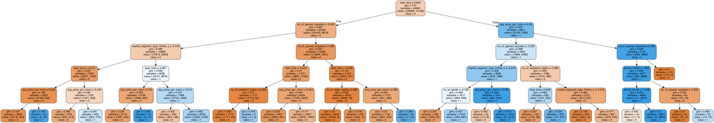

```python
from sklearn.tree import export_graphviz
from sklearn.externals.six import StringIO
from IPython.display import Image
import pydotplus

dot_data = StringIO()
export_graphviz(clf, out_file=dot_data,
                filled=True, rounded=True,
                special_characters=True,feature_names = X.columns,class_names=['0','1'])
graph = pydotplus.graph_from_dot_data(dot_data.getvalue())
graph.write_png('diabetes.png')
Image(graph.create_png())
```

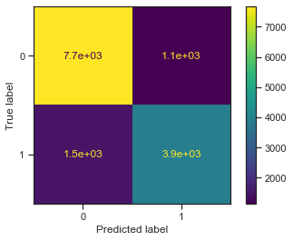

```python
plot_confusion_matrix(clf, X_test, y_test)
plt.show()
```

```
No Skill: ROC AUC=0.500
Decision Tree: ROC AUC=0.875
```

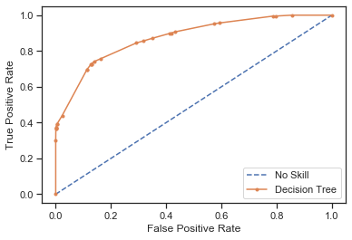

```python
ns_probs = [0 for _ in range(len(y_test))]

# predict probabilities
lr_probs = clf.predict_proba(X_test)
# keep probabilities for the positive outcome only
lr_probs = lr_probs[:, 1]
# calculate scores
ns_auc = roc_auc_score(y_test, ns_probs)
lr_auc = roc_auc_score(y_test, lr_probs)
# summarize scores
print('No Skill: ROC AUC=%.3f' % (ns_auc))
print('Decision Tree: ROC AUC=%.3f' % (lr_auc))
# calculate roc curves
ns_fpr, ns_tpr, _ = roc_curve(y_test, ns_probs)
lr_fpr, lr_tpr, _ = roc_curve(y_test, lr_probs)
# plot the roc curve for the model
pyplot.plot(ns_fpr, ns_tpr, linestyle='--', label='No Skill')
pyplot.plot(lr_fpr, lr_tpr, marker='.', label='Decision Tree')
# axis labels
pyplot.xlabel('False Positive Rate')
pyplot.ylabel('True Positive Rate')
# show the legend
pyplot.legend()
# show the plot
pyplot.show()
```

## Conclusion :

The Model predicts the cancellation withnthe acccuracy of .816 , which will be able to predict in cancellation of Bookings based on the createria